# Bulk RNA Seq - PCA and Heat Maps

Brandon Hancock

1/15/2021

This page shows how pca plot and heatmaps were generated for this paper

Analysis derived from the DESeq2 [tutorial](http://bioconductor.org/packages/release/bioc/vignettes/DESeq2/inst/doc/DESeq2.html)

Load the required R packages:

```r
library(readxl)
library(readr)
library(DESeq2)
library(pheatmap)
library(ggplot2)
```

Load in the Bulk RNA seq STAR gene counts file:

```r
STAR_gene_counts <- read_csv("C:/Users/bh719/Dropbox (Partners HealthCare)/Harvard CyTof/for Brandon/Sally/STAR_Gene_Counts.csv")
```

Remove genes with duplicate entries (1-Mar and 2-Mar)

```r
STAR_gene_counts <- STAR_gene_counts[!duplicated(STAR_gene_counts$Gene_ID),]
```

Define Meta Data

```r
colmetadat <- data.frame(Injury = c(rep("Uninjured",9),rep("7D after Injury",10)),CD44 = c(rep("CD44 High",4),rep("CD44 Low",5),rep("CD44 High",4),rep("CD44 Low",6)))
row.names(colmetadat) <- colnames(STAR_gene_counts)[2:length(colnames(STAR_gene_counts))]
```

Define DESeq2 matrix

```r
gene_row <- STAR_gene_counts$Gene_ID
cmat <- STAR_gene_counts
cmat <- cmat[,!(names(cmat) %in% c('Gene_ID'))]
row.names(cmat) <- gene_row
```

Create DESeq2 object

```r
dds <- DESeqDataSetFromMatrix(countData = cmat,colData = colmetadat,design = ~ CD44 + Injury)
dds <- dds[rowSums(counts(dds)) >= 10,]
dds$group <- factor(paste0(dds$CD44,dds$Injury))
design(dds) <- ~ group
```

Create the PCA plot

```r
vsd <- vst(dds,blind = FALSE)
```

```
##   Note: levels of factors in the design contain characters other than
##   letters, numbers, '_' and '.'. It is recommended (but not required) to use
##   only letters, numbers, and delimiters '_' or '.', as these are safe characters
##   for column names in R. [This is a message, not a warning or an error]
```

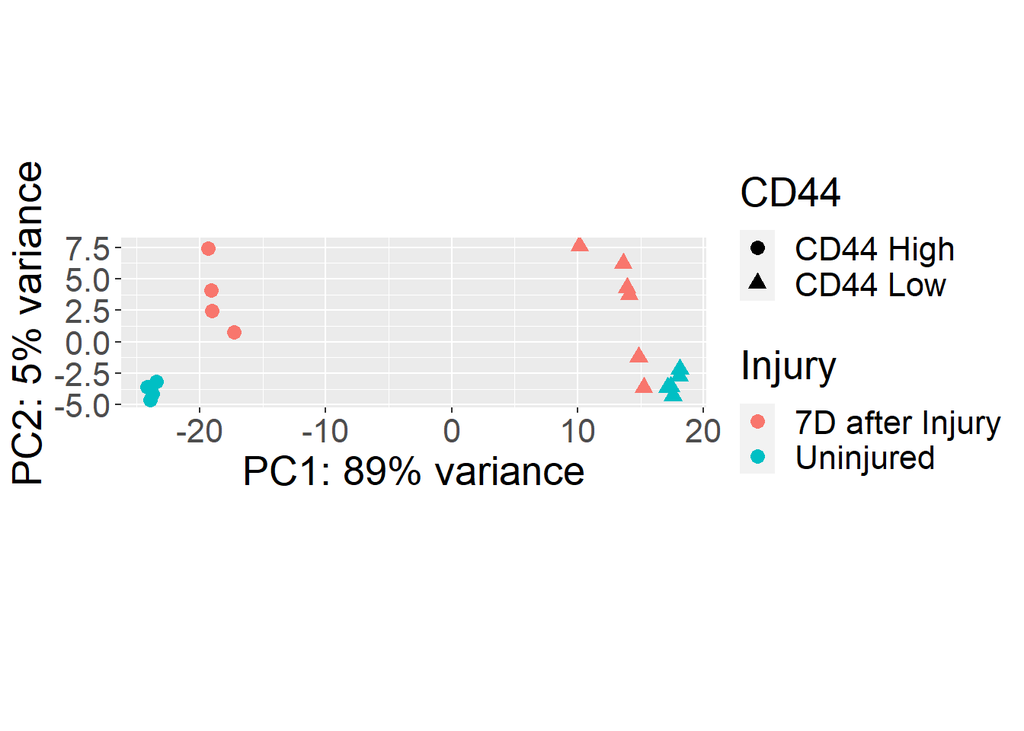

```r
pcaData <- plotPCA(vsd, intgroup=c("Injury","CD44"), returnData = TRUE)
percentVar <- round(100 * attr(pcaData, "percentVar"))
ggplot(pcaData, aes(PC1, PC2, color = Injury, shape = CD44)) + geom_point(size=3) +
  xlab(paste0("PC1: ",percentVar[1],"% variance")) +
  ylab(paste0("PC2: ",percentVar[2],"% variance")) +
  coord_fixed() +
  theme(text = element_text(size = 20))
```

Define function to calculate variance (stabilized, from vst) of each gene

```r
f_get_var <- function(vsd){
  var_list <- c()
  gene_ids <- row.names(vsd)
  for (i in 1:length(gene_ids)){
    gene_row <- as.vector(vsd[gene_ids[i],])
    gene_vec <- c()
    for (j in 1:length(gene_row)){
      gene_vec <- c(gene_vec,gene_row[[j]])
    }
    var_list[gene_ids[i]] <- var(gene_vec)
  }
  return(var_list)
}
```

Get the 2000 genes with the highest variance

```r
var_list <- f_get_var(assay(vsd))
var_list <- var_list[order(var_list,decreasing = TRUE)]
gene_list <- head(names(var_list),2000)
```

Use prefixes to find cytokines and cell surface markers from the high variance genes

```r
diff_cytokines_cd <- gene_list[grep("^CCL|^CXC|^IFN|^IL|^TNF|CD40LG|FASL|CD70|TGFB|^CD[[:digit:]]",gene_list)]
```

Define a set of genes with known Treg activity

```r
treg_genes <- c("TGFB","IL10","ENTPD1","NT5E","LAG3",'TIGIT','CTLA4','ITGAE','KLRG1','ICOS','IL10RA','FGL2','HAVCR2','CD83')
```

Combine lists to create heat map gene list

```r
gene_list_heat_cyto <- c(diff_cytokines_cd,treg_genes)
gene_list_heat_cyto <- gene_list_heat_cyto[gene_list_heat_cyto %in% gene_list]
gene_list_heat_cyto <- gene_list_heat_cyto[!duplicated(gene_list_heat_cyto)]
```

Define the heatmap by subsetting genes from the gene count table

```r
curr_heat <- STAR_gene_counts[STAR_gene_counts$Gene_ID %in% gene_list_heat_cyto,]
heat_names <- curr_heat$Gene_ID
curr_heat <- curr_heat[,!(names(curr_heat) %in% c('Gene_ID'))]
row.names(curr_heat) <- heat_names
```

Define function to scale gene count values and apply to heat map

```r
cal_z_score <- function(x){
  (x - mean(x)) / sd(x)
}

curr_heat <- t(apply(curr_heat, 1, cal_z_score))
```

Define function to change capitalization

```r
Cap <- function(g){
  g <- paste(toupper(substring(g,1,1)), tolower(substring(g,2)), sep = '')
  return(g)
}
```

Define the gene annotation, ‘Treg’ or ‘Other’

```r
treg_annot <- c()
  for (i in 1:length(toupper(gene_list_heat_cyto))){
    if(gene_list_heat_cyto[i] %in% treg_genes){
      treg_annot <- c(treg_annot,'Treg Activity')
    } else {
      treg_annot <- c(treg_annot,"Other")
    }
  }
names(treg_annot) <- gene_list_heat_cyto
names(treg_annot) <- sapply(names(treg_annot), Cap)
gene_row_annot <- data.frame(Treg = treg_annot)
```

Define the sample meta data for the heat map

```r
CD44 <- data.frame(CD44 = c(rep("CD44 High",4),rep("CD44 Low",5),rep("CD44 High",4),rep("CD44 Low",6)))
row.names(CD44) <- colnames(curr_heat)
Injury <- data.frame(Injury = c(rep("Uninjured",9),rep("7D after Injury",10)))
row.names(Injury) <- colnames(curr_heat)
sample_col_annot <- cbind(CD44,Injury)
```

Define colors for meta data

```r
annot_colors <- list(Treg = c('Treg Activity' = '#20B2AA','Other' = '#DCDCDC'),
                     Injury = c('Uninjured' = '#474443','7D after Injury' = '#FFA500'),
                     CD44 = c('CD44 High' = '#9932CC', 'CD44 Low' = '#FFB6C1'))
```

Make the heat map

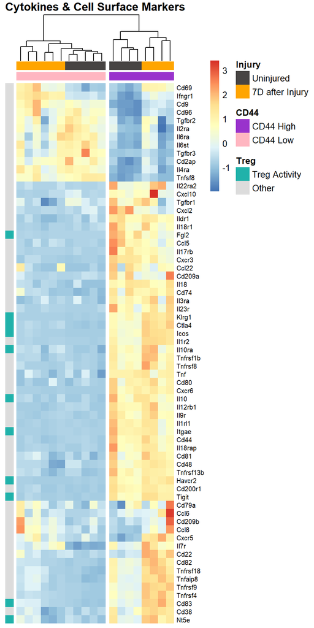

```r
row.names(curr_heat) <- sapply(row.names(curr_heat), Cap)
names(gene_row_annot) <- sapply(names(gene_row_annot), Cap)

pheatmap(curr_heat, annotation_row = gene_row_annot,annotation_colors = annot_colors,cutree_cols = 2,annotation_col = sample_col_annot,annotation_names_col = FALSE,annotation_names_row = FALSE,show_colnames = FALSE,fontsize_row = 7.5,main ='Cytokines & Cell Surface Markers',border_color = NA, treeheight_row = 0)
```

For the heat map of transcription factors, we must look up gene ontology information. I use the mygene package here

```r
library(mygene)
res <- queryMany(gene_list,scopes = 'symbol', fields=c('entrezgene','ensembl.gene','go','description'),species = 'mouse')
```

```
## Querying chunk 1
```

```
## Querying chunk 2
```

```
## Finished
## Pass returnall=TRUE to return lists of duplicate or missing query terms.
```

```r
res <- res[!duplicated(res$query),]
```

Define functions to search the mygene query

```r
f_getMF <- function(res,gene){
  MF <- res[which(res$query == gene),]$go.MF[[1]]
  return(MF)
}

f_transcription_genes <- function(res,genes){
  tgenes <- c()
  for (i in 1:length(genes)){
    if (length(grep('transcription factor',f_getMF(res,genes[i])$term)) > 0){
      tgenes <- c(tgenes,i)
    }
  }
  return(genes[tgenes])
}
```

Get list of transcription factors with the highest variance (66 genes to match the cytokine heatmap)

```r
diff_transcription_facs <- f_transcription_genes(res,gene_list)
diff_transcription_facs <- diff_transcription_facs[1:66]
```

Construct the heatmap as before

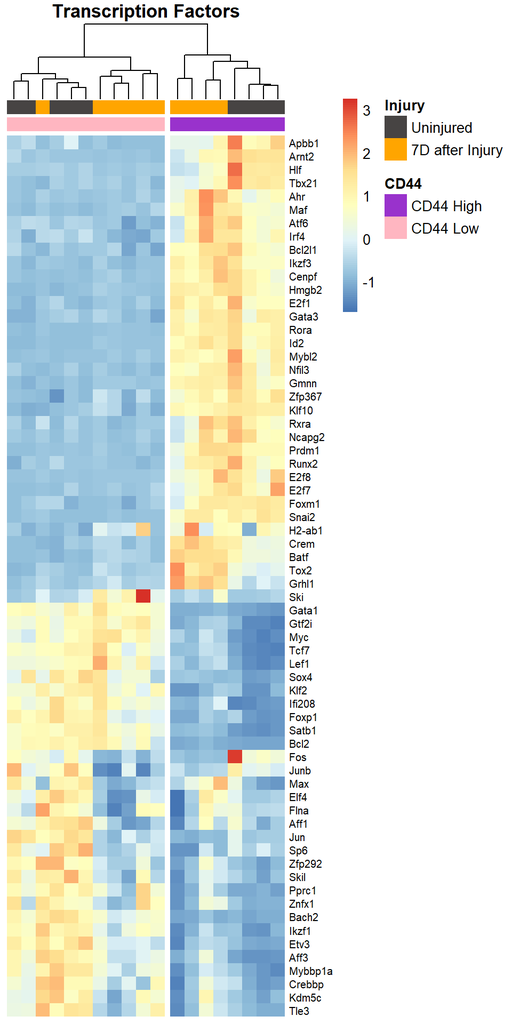

```r
curr_heat <- STAR_gene_counts[STAR_gene_counts$Gene_ID %in% diff_transcription_facs,]
heat_names <- curr_heat$Gene_ID
curr_heat <- curr_heat[,!(names(curr_heat) %in% c('Gene_ID'))]
row.names(curr_heat) <- heat_names
curr_heat <- t(apply(curr_heat, 1, cal_z_score))
annot_colors <- list(Injury = c('Uninjured' = '#474443','7D after Injury' = '#FFA500'),
                     CD44 = c('CD44 High' = '#9932CC', 'CD44 Low' = '#FFB6C1'))
CD44 <- data.frame(CD44 = c(rep("CD44 High",4),rep("CD44 Low",5),rep("CD44 High",4),rep("CD44 Low",6)))
row.names(CD44) <- colnames(curr_heat)
Injury <- data.frame(Injury = c(rep("Uninjured",9),rep("7D after Injury",10)))
row.names(Injury) <- colnames(curr_heat)
sample_col_annot <- cbind(CD44,Injury)

row.names(curr_heat) <- sapply(row.names(curr_heat), Cap)
pheatmap(curr_heat,annotation_colors = annot_colors,cutree_cols = 2,annotation_col = sample_col_annot,annotation_names_col = FALSE,annotation_names_row = FALSE,show_colnames = FALSE,fontsize_row = 7.5,main ='Transcription Factors',border_color = NA, treeheight_row = 0)
```

Session Info

```r
installed.packages()[names(sessionInfo()$otherPkgs), "Version"]
```

```
##               mygene      GenomicFeatures        AnnotationDbi
##             "1.26.0"             "1.42.3"             "1.52.0"
##              ggplot2             pheatmap               DESeq2
##              "3.3.3"             "1.0.12"             "1.30.1"
## SummarizedExperiment              Biobase       MatrixGenerics
##             "1.20.0"             "2.50.0"              "1.2.1"
##          matrixStats        GenomicRanges         GenomeInfoDb
##             "0.58.0"             "1.42.0"             "1.26.7"
##              IRanges            S4Vectors         BiocGenerics
##             "2.24.1"             "0.28.1"             "0.36.1"
##                readr               readxl
##              "1.4.0"              "1.3.1"
```